# R Notebook

```r
library(tidyverse)
library(dplyr)
```

```r
books_data <- read_csv("data/books.csv")
```

```
21 parsing failures.
 row            col           expected            actual             file
1570 title          delimiter or quote                   'data/books.csv'
1570 title          delimiter or quote I                 'data/books.csv'
3349 average_rating a double           Jr./Sam B. Warner 'data/books.csv'
3349 num_pages      a double           en-US             'data/books.csv'
3349 NA             12 columns         13 columns        'data/books.csv'
.... .............. .................. ................. ................
See problems(...) for more details.
```

#Investigating the data, exploring the dimensions, missing data and number of distinct values in the dataset

```r
books_data %>%
summarise(count = is.na(books_data))
```

| count |
| --- |

[output cut: 990 more lines]

```r
which(is.na(books_data))
```

```
 [1]  25416  28765  32902  33888  42360  50832  59304  62653  66790  67776  76248  84720  93192
[14] 101664
```

```r
n_distinct(books_data)
```

```
[1] 8472
```

#Dropped the missing values and publisher, isbn and isbn13

```r
clean_books_data <- na.omit(books_data)
clean_books_data_dropped <- select(clean_books_data, -publisher, -isbn, -isbn13)
```

#Created a new column that specifies if the number of pages in each book is greater than 1000 or less than 1000

```r
clean_books_data_dropped %>%
  select(num_pages) %>%
  mutate(page_number_sum = if_else(num_pages >= 1000, "Greater than or equal to 1000", "Less than 1000"))
```

| num_pages | page_number_sum |
| --- | --- |
| 652 | Less than 1000 |
| 870 | Less than 1000 |
| 352 | Less than 1000 |
| 435 | Less than 1000 |
| 2690 | Greater than or equal to 1000 |
| 152 | Less than 1000 |
| 3342 | Greater than or equal to 1000 |
| 815 | Less than 1000 |
| 815 | Less than 1000 |
| 215 | Less than 1000 |

[output cut: 990 more lines]

#A simple plot of the relationship bewteen book length and book average rating #This plot does not really show anything particularly informative, other than the fact the majority of books are between 0 and 1500 pages and most reviews are 3 and above

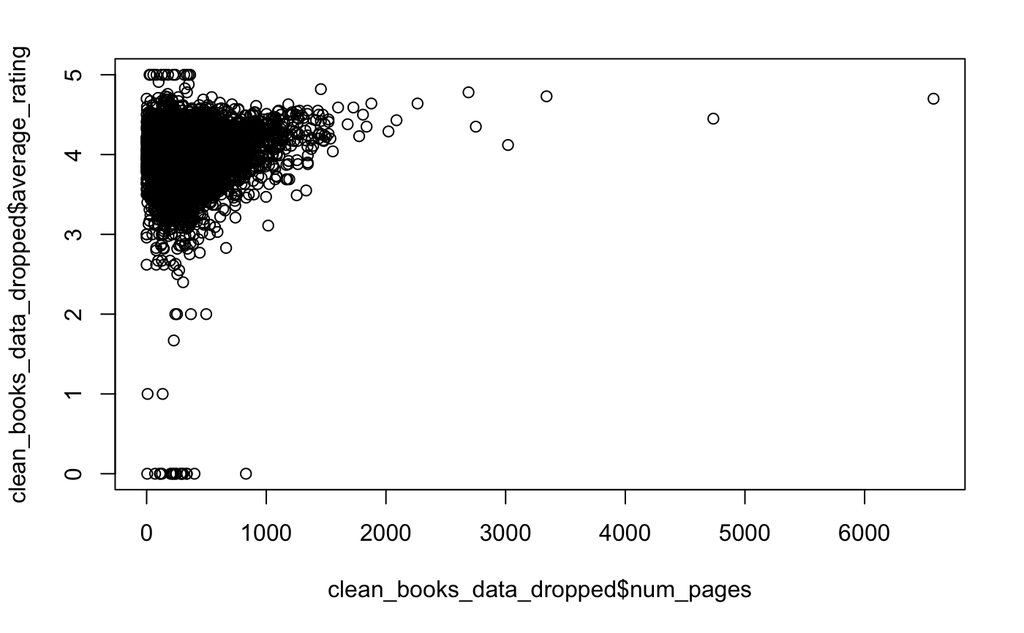

```r
plot(clean_books_data_dropped$num_pages, clean_books_data_dropped$average_rating)
```

#A simple correlation test between number of pages and average rating showed very minimal, if any, correlation - given 0.2 is considered a weak correlation, and 1.0 is a perfect correlation.

```r
cor(clean_books_data_dropped$num_pages, clean_books_data_dropped$average_rating)
```

```
[1] 0.1550904
```

```r
library(Hmisc)
```

#Using the Hmisc package to perform pearson and spearman correlation tests

```r
rcorr(clean_books_data_dropped$num_pages, clean_books_data_dropped$average_rating, type=c("pearson"))
```

```
     x    y
x 1.00 0.16
y 0.16 1.00

n= 8469


P
  x  y
x     0
y  0
```

```r
rcorr(clean_books_data_dropped$num_pages, clean_books_data_dropped$average_rating, type=c("spearman"))
```

```
     x    y
x 1.00 0.11
y 0.11 1.00

n= 8469


P
  x  y
x     0
y  0
```

#How frequently do authors appear in the dataset

```r
clean_books_data_dropped %>%
  group_by(authors) %>%
  summarise(total_author_appearances = n())
```

| authors | total_author_appearances |
| --- | --- |
| A.B. Yehoshua/Hillel Halkin | 2 |
| A.J. Jacobs | 1 |
| A.M. Homes | 1 |
| A.N. Roquelaure/Anne Rice | 3 |
| A.S. Byatt | 1 |
| Abbie Hoffman/Anita Hoffman | 1 |
| Abdul Rahman Munif/Peter Theroux | 1 |
| Abigail Adams/Frank Shuffelton | 1 |
| Abigail Thomas | 1 |
| Abolqasem Ferdowsi/Dick Davis/Azar Nafisi | 1 |

[output cut: 990 more lines]

#Finding the mean average rating for each author and selecting the top 20 average ratings

```r
clean_books_data_dropped %>%
  group_by(authors) %>%
  summarise(mean_rating = mean(average_rating)) %>%
  slice_max(mean_rating, n = 20)
```

| authors | mean_rating |
| --- | --- |
| Aristophanes/F.W. Hall/W.M. Geldart | 5.000000 |
| Chris Green/Chris Wright/Paul Douglas Gardner | 5.000000 |
| James E. Campbell | 5.000000 |
| Julie Sylvester/David Sylvester | 5.000000 |
| Keith Donohue | 5.000000 |
| Laura Driscoll/Alisa Klayman-Grodsky/Eric Weiner | 5.000000 |
| Middlesex Borough Heritage Committee | 5.000000 |
| Nicholas Evans/Rhonda Evans | 5.000000 |
| Ross Garnaut | 5.000000 |
| Sheri Rose Shepherd | 5.000000 |

[output cut: 10 more lines]

#Putting the number of ratings for each book into the category of few, some or many

```r
rating_frequency <- clean_books_data_dropped %>%
  mutate(
   ratings_count = case_when(
      ratings_count < 1000 ~ "Few ratings",
      ratings_count < 100000 ~ "Some ratings",
      ratings_count >= 100000 ~ "Many ratings"
      )
    )
rating_frequency
```

[output not shown]

```r
clean_books_data_dropped %>%
  arrange(num_pages
  )
```

| bookID | title | authors | average_rating | language_code | num_pages | ratings_count | text_reviews_count | publication_date |
| --- | --- | --- | --- | --- | --- | --- | --- | --- |
| 955 | The 5 Love Languages / The 5 Love Languages Journal | Gary Chapman | 4.70 | eng | 0 | 22 | 4 | 1/1/2005 |
| 2835 | The Tragedy of Pudd'nhead Wilson | Mark Twain/Michael Prichard | 3.79 | eng | 0 | 3 | 0 | 1/1/2003 |
| 3593 | Murder by Moonlight & Other Mysteries (New Adventures of Sherlock Holmes 19-24) | NOT A BOOK | 4.00 | eng | 0 | 7 | 2 | 10/3/2006 |
| 3599 | The Unfortunate Tobacconist & Other Mysteries (Sherlock Holmes 1-6) | NOT A BOOK | 3.50 | eng | 0 | 12 | 1 | 10/1/2003 |
| 4249 | The Da Vinci Code (Robert Langdon #2) | Dan Brown/Paul Michael | 3.84 | eng | 0 | 91 | 16 | 3/28/2006 |
| 5362 | The Summons / The Brethren | John Grisham/Michael Beck/Frank Muller | 3.99 | eng | 0 | 241 | 9 | 10/10/2006 |
| 6542 | The Patricia Cornwell CD Audio Treasury: All That Remains / Cruel & Unusual (Kay Scarpetta #3 #4) | Patricia Cornwell/Kate Burton | 4.16 | eng | 0 | 202 | 1 | 7/26/2005 |
| 6953 | Like Water for Chocolate | Laura Esquivel/Yareli Arizmendi | 3.95 | eng | 0 | 121 | 33 | 5/2/2006 |
| 7598 | A Study Guide to Gabriel Garcia Marquez' One Hundred Years of Solitude | Gabriel García Márquez/Brenda K. Marshall/F. Murray Abraham | 4.11 | eng | 0 | 75 | 2 | 4/1/2006 |
| 7674 | The Michael Crichton Collection: Airframe / The Lost World / Timeline | Michael Crichton/Stephen Lang/Anthony Heald/Blair Brown | 4.16 | en-GB | 0 | 267 | 7 | 8/29/2006 |

[output cut: 990 more lines]

```r
clean_books_data_dropped %>%
  filter(num_pages != 0)
```

| bookID | title | authors | average_rating | language_code | num_pages | ratings_count | text_reviews_count | publication_date |
| --- | --- | --- | --- | --- | --- | --- | --- | --- |
| 1 | Harry Potter and the Half-Blood Prince (Harry Potter #6) | J.K. Rowling/Mary GrandPré | 4.57 | eng | 652 | 2095690 | 27591 | 9/16/2006 |
| 2 | Harry Potter and the Order of the Phoenix (Harry Potter #5) | J.K. Rowling/Mary GrandPré | 4.49 | eng | 870 | 2153167 | 29221 | 9/1/2004 |
| 4 | Harry Potter and the Chamber of Secrets (Harry Potter #2) | J.K. Rowling | 4.42 | eng | 352 | 6333 | 244 | 11/1/2003 |
| 5 | Harry Potter and the Prisoner of Azkaban (Harry Potter #3) | J.K. Rowling/Mary GrandPré | 4.56 | eng | 435 | 2339585 | 36325 | 5/1/2004 |
| 8 | Harry Potter Boxed Set Books 1-5 (Harry Potter #1-5) | J.K. Rowling/Mary GrandPré | 4.78 | eng | 2690 | 41428 | 164 | 9/13/2004 |
| 9 | Unauthorized Harry Potter Book Seven News: "Half-Blood Prince" Analysis and Speculation | W. Frederick Zimmerman | 3.74 | en-US | 152 | 19 | 1 | 4/26/2005 |
| 10 | Harry Potter Collection (Harry Potter #1-6) | J.K. Rowling | 4.73 | eng | 3342 | 28242 | 808 | 9/12/2005 |
| 12 | The Ultimate Hitchhiker's Guide: Five Complete Novels and One Story (Hitchhiker's Guide to the Galaxy #1-5) | Douglas Adams | 4.38 | eng | 815 | 3628 | 254 | 11/1/2005 |
| 13 | The Ultimate Hitchhiker's Guide to the Galaxy (Hitchhiker's Guide to the Galaxy #1-5) | Douglas Adams | 4.38 | eng | 815 | 249558 | 4080 | 4/30/2002 |
| 14 | The Hitchhiker's Guide to the Galaxy (Hitchhiker's Guide to the Galaxy #1) | Douglas Adams | 4.22 | eng | 215 | 4930 | 460 | 8/3/2004 |

[output cut: 990 more lines]